# Manipulating Data with Style in SQL

## Polyglot Programming DC : October 2014 Meetup

**Author:** [Ryan B. Harvey](http://datascientist.guru)

**Created:** 2014-07-17 / **Last Updated:** 2014-10-13

**Contents:**

- The `sqldf` package: SQL on dataframes in R
- Loading some test data
- Querying and subsetting that test data
- Example of a complex query

**Package Dependencies:**

- **sqldf:** Perform SQL Selects on R Data Frames. R package version 0.4-7.1. Author: G. Grothendieck (2014) [more info & source](https://code.google.com/p/sqldf/)

**References:**

- This RPub was originally created for a talk to the Data Wranglers DC meetup group on August 6, 2014, and is updated for a talk to the Polyglot Programming DC meetup group on October 14, 2014.
  - August talk information: http://www.meetup.com/Data-Wranglers-DC/events/177269432/
  - October talk information: http://www.meetup.com/Polyglot-Programming-DC/events/208670052/
  - This is only a portion of the talk, which included database information, SQL code, an [IPython notebook](http://nbviewer.ipython.org/github/nihonjinrxs/polyglot-october2014/blob/master/python/sqldf_examples_python.ipynb).
  - My code, slides and the sample data are all available on Github. https://github.com/nihonjinrxs/polyglot-october2014

The `sqldf` package is an R package that creates tables in a local SQLite database, runs the requested SQL query on those tables, and then drops the tables from the SQLite database. Although this can be slower than subsetting a data frame directly, in cases where the data frame is very complex and conditions get difficult to parse, SQL can provide a straightforward, declarative way of requesting a particular data subset.

If the `sqldf` package doesn't exist in your environment, install the package. Once you have it, require it.

```r
# install.packages("sqldf")
require(sqldf)
```

Note that the `sqldf` package will use SQLite as a default, unless a different database driver package is currently loaded (i.e., If we would like `sqldf` to use a different database product, we can tell it which driver to use by specifying that in the options statement.

```r
# options(sqldf.driver = "SQLite")
```

For example, if you wanted to use some of the functions available in PostgreSQL, you could use that as the driver for `sqldf` by loading the `RPosgreSQL` package first. More details on this are at [How does one use sqldf with PosrgreSQL?](https://code.google.com/p/sqldf/#12._How_does_one_use_sqldf_with_PostgreSQL?).

## Load some data to work with

For this example, we'll use the [Basic Business Licenses data](http://data.dc.gov/Main_DataCatalog.aspx?id=1520) from the [DC government open data site](http://data.dc.gov/).

The data is available as a zip file, so we'll download it if it's not already available, and then unzip it if it hasn't been already.

```r
url = "http://data.octo.dc.gov/feeds/bbl/bbl_current_csv.zip"
data_dir = "../data/"
current_dir = getwd()
setwd(data_dir)
local_zipped = "bbl_current_csv.zip"
local_data = "bbl_current_csv.csv"
if (!(file.exists(local_data) && file.exists(local_zipped))) {
  download.file(url, destfile=local_zipped, method="curl")
  fileDownloadedDate <- date()
  paste("File downloaded at ", fileDownloadedDate)
}
if (!file.exists(local_data)) {
  unzip(local_zipped)
}
bbl <- read.csv(local_data)
setwd(current_dir)
```

Now that we have the data frame `bbl`, let's take a look at what's in it.

```r
head(bbl)
```

```
##   BBL_LICENSE_FACT_ID        LICENSESTATUS             LICENSECATEGORY
## 1              144376            CANCELLED     Charitable Solicitation
## 2              146806            CANCELLED   General Business Licenses
## 3              151842            CANCELLED         Cigarette Wholesale
## 4              152391               ACTIVE Gen Contr-Construction Mngr
## 5              162782 READY TO BATCH PRINT           One Family Rental
## 6              164337 READY TO BATCH PRINT           One Family Rental
##    CUST_NUM                           TRADE_NAME   LICENSE_START_DATE
## 1 6.599e+07  WASHINGTON ARCHITECTURAL FOUNDATION 9/1/2011 12:00:00 AM
## 2 4.003e+11                                      3/1/2012 12:00:00 AM
## 3 4.104e+11               WAREHOUSE ON THE WHEEL 7/1/2011 12:00:00 AM
## 4 4.105e+11                 REDLINE PROJECTS LLC 4/1/2014 12:00:00 AM
## 5 5.005e+11 THE DUMAN KIM 2008 IRREVOCABLE TRUST 3/1/2014 12:00:00 AM
## 6 6.600e+07       LAWRENCE PLUTKIN & RUTH HANSEN 5/1/2014 12:00:00 AM
##   LICENSE_EXPIRATION_DATE    LICENSE_ISSUE_DATE AGENT_PHONE
```

[output cut: 41 more lines]

```r
summary(bbl)
```

```
##  BBL_LICENSE_FACT_ID              LICENSESTATUS
##  Min.   :144376      ACTIVE              :65
##  1st Qu.:242791      CANCELLED           : 4
##  Median :269696      READY TO BATCH PRINT:45
##  Mean   :252478
##  3rd Qu.:272597
##  Max.   :272625
##
##                     LICENSECATEGORY    CUST_NUM
##  One Family Rental          :44     Min.   :3.95e+07
##  Charitable Solicitation    :14     1st Qu.:7.01e+07
##  General Business Licenses  :14     Median :4.00e+11
##  Restaurant                 :10     Mean   :3.58e+11
##  Cigarette Retail           : 9     3rd Qu.:5.01e+11
##  Gen Contr-Construction Mngr: 4     Max.   :9.31e+11
##  (Other)                    :19
##                                TRADE_NAME            LICENSE_START_DATE
##                                     :18   7/1/2014 12:00:00 AM:58
##  COLDWELL BANKER PROPERTY MANAGEMENT: 4   8/1/2014 12:00:00 AM:25
##  NEHEMIAH ESTATES COOPERATIVE       : 4   9/1/2014 12:00:00 AM:18
##  MHF NOMA OPERATING IV LLC          : 3   5/1/2014 12:00:00 AM: 5
##  YARMOUTH MANAGEMENT                : 3   6/1/2014 12:00:00 AM: 2
##  ALAZAR INC                         : 2   3/1/2012 12:00:00 AM: 1
##  (Other)                            :80   (Other)             : 5
##           LICENSE_EXPIRATION_DATE             LICENSE_ISSUE_DATE
##  6/30/2016 12:00:00 AM:58         7/12/2014 12:00:00 AM:  1
##  7/31/2016 12:00:00 AM:25         7/15/2014 12:00:00 AM:113
##  8/31/2016 12:00:00 AM:18
##  4/30/2016 12:00:00 AM: 5
##  5/31/2016 12:00:00 AM: 2
##  2/28/2014 12:00:00 AM: 1
##  (Other)              : 5
##      AGENT_PHONE             LASTMODIFIEDDATE         CITY     STATE
##            :11   7/17/2014 6:45:37 AM:58                :  8     :  8
##  9999999999: 6   7/17/2014 6:45:38 AM:56      WASHINGTON:106   DC:106
##  2024715201: 4
##  2405653160: 4
##  8004831140: 4
##  2025473511: 3
##  (Other)   :82
```

[output cut: 25 more lines]

```
##  6      :15          NONE:114        NONE:114        NONE:114
##  21     : 9
##  25     : 9
##  8      : 8
##  NONE   : 8
##  26     : 7
##  (Other):58
##       BUSINESSIMPROVEMENTDISTRICT
##  NONE               :91
##  DOWNTOWN BID       : 8
##  GOLDEN TRIANGLE BID: 7
##  NOMA BID           : 4
##  ADAMS MORGAN BID   : 1
##  CAPITOL HILL BID   : 1
##  (Other)            : 2
```

## SQL Queries on Data Frames

Now, let's do a few queries on it just to get the hang of using `sqldf`.

```r
sqldf("select * from bbl where BUSINESSIMPROVEMENTDISTRICT = 'DOWNTOWN BID'")
```

```
##   BBL_LICENSE_FACT_ID        LICENSESTATUS            LICENSECATEGORY
## 1              168986               ACTIVE                      Hotel
## 2              240380 READY TO BATCH PRINT  General Business Licenses
## 3              240701               ACTIVE           Cigarette Retail
## 4              249449               ACTIVE    Charitable Solicitation
## 5              249571 READY TO BATCH PRINT          One Family Rental
## 6              272574               ACTIVE    Charitable Solicitation
## 7              272576               ACTIVE    Charitable Solicitation
## 8              272589               ACTIVE Parking Facility Attendant
##    CUST_NUM                               TRADE_NAME   LICENSE_START_DATE
## 1 5.001e+07                    CCMH METRO CENTER LLC 5/1/2014 12:00:00 AM
## 2 7.011e+07 KIPLINGER WASHINGTON EDITORS, INC. (THE) 9/1/2014 12:00:00 AM
## 3 5.300e+07                        MAHIL CORPORATION 8/1/2014 12:00:00 AM
## 4 4.002e+11       WASHINGTON AREA WOMEN'S FOUNDATION 8/1/2014 12:00:00 AM
## 5 5.005e+11                                          8/1/2014 12:00:00 AM
```

[output cut: 57 more lines]

```r
sqldf("select * from bbl where WARD = 6")
```

```
##    BBL_LICENSE_FACT_ID        LICENSESTATUS           LICENSECATEGORY
## 1               164337 READY TO BATCH PRINT         One Family Rental
## 2               239799 READY TO BATCH PRINT   Charitable Solicitation
## 3               242055 READY TO BATCH PRINT         One Family Rental
## 4               242787 READY TO BATCH PRINT         One Family Rental
## 5               245630            CANCELLED          Cigarette Retail
## 6               245768               ACTIVE                Restaurant
## 7               248720 READY TO BATCH PRINT         One Family Rental
## 8               249244 READY TO BATCH PRINT         One Family Rental
## 9               249666 READY TO BATCH PRINT         One Family Rental
## 10              249875 READY TO BATCH PRINT         One Family Rental
## 11              272577               ACTIVE   Charitable Solicitation
## 12              272580               ACTIVE General Business Licenses
## 13              272584               ACTIVE General Business Licenses
## 14              272593               ACTIVE         One Family Rental
```

[output cut: 153 more lines]

The `sqldf()` function returns a data frame, so we can store it in another variable for use in a plot, for example.

```r
ward6 <- sqldf("select LICENSECATEGORY, count(*) as LICENSECOUNT from bbl where WARD = 6 group by LICENSECATEGORY")
ward6
```

```
##             LICENSECATEGORY LICENSECOUNT
## 1   Charitable Solicitation            2
## 2          Cigarette Retail            1
## 3             Food Products            1
## 4 General Business Licenses            2
## 5                     Hotel            1
## 6         One Family Rental           11
## 7                Restaurant            1
## 8             Swimming Pool            1
```

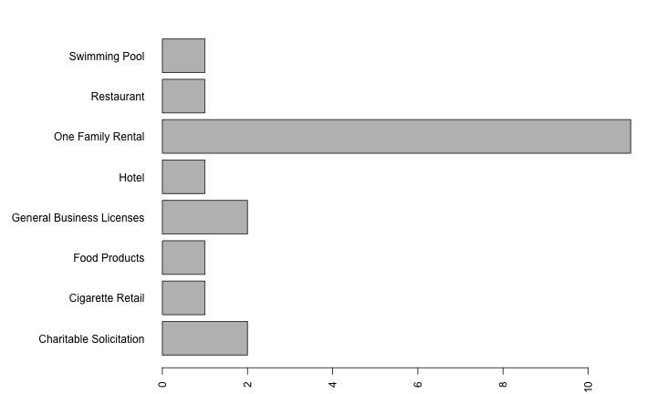

```r
par(las=2, mar=c(2, 12, 2, 2)) # Labels perpendicular to axis, wide left margin
barplot(ward6$LICENSECOUNT, names.arg=ward6$LICENSECATEGORY, horiz=TRUE)
```

Next, let's try to plot a cross-tab of license status vs. license category.

```r
ward6detail <- sqldf("select LICENSECATEGORY, LICENSESTATUS, BBL_LICENSE_FACT_ID from bbl where WARD = 6 order by LICENSECATEGORY, LICENSESTATUS")
head(ward6detail)
```

```
##             LICENSECATEGORY        LICENSESTATUS BBL_LICENSE_FACT_ID
## 1   Charitable Solicitation               ACTIVE              272577
## 2   Charitable Solicitation READY TO BATCH PRINT              239799
## 3          Cigarette Retail            CANCELLED              245630
## 4             Food Products               ACTIVE              272618
## 5 General Business Licenses               ACTIVE              272580
## 6 General Business Licenses               ACTIVE              272584
```

```r
ward6xtabs <- xtabs(~LICENSESTATUS+LICENSECATEGORY, data=ward6detail)
```

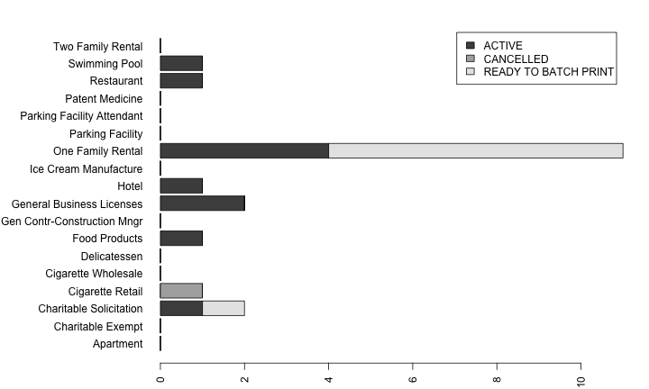

```r
par(las=2, mar=c(2, 12, 2, 2)) # Labels perpendicular to axis, wide left margin
barplot(ward6xtabs, horiz=TRUE, legend=rownames(ward6xtabs))
```

## Example of a More Complex Query

```r
query <-
"select BBL_LICENSE_FACT_ID as bbl_id,
LATITUDE as lat, LONGITUDE as lon,
WARD as ward, LICENSESTATUS as status,
BUSINESSIMPROVEMENTDISTRICT as bid
from bbl
where LICENSESTATUS != 'CANCELLED'
and WARD != 'NA'
and LATITUDE <> 0
AND LONGITUDE <> 0"

results <- sqldf(query)
```

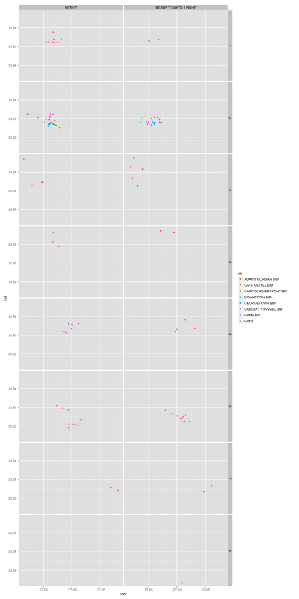

```r
library(ggplot2)
qplot(lon, lat, data=results, facets=ward~status, col=bid)
```